## HTML & CSS

# HTML & CSS

# Document Structure

- labor1.html [code](https://github.com/mcuringa/teaching-labor/blob/master/web/labor1.html) uses basic html structures to format the page
- header tags: `h1, h2, h3, h4`
- paragraph tag: `p`
- bold and italic: `strong`, `em` (emphasis)
- un-ordered list: `ul`, `li`

# Declaring an html document

```html
<!DOCTYPE html>
<html>
    <head>
        <title>Teaching Labor, an Adelphi University MOOC</title>
    </head>

    <body>
```

# Links

# Hyper Links

- links make the Web what it his
- HTML –> hyper text markup language
  - not the first/only type of hypertext
  - allows documents on different computers to link to each other
- thinks we link to:
  - other web pages
  - images (photos, etc)
  - video
  - audio
  - javascript resources
  - cascading stylesheets (css)

# URL Basics

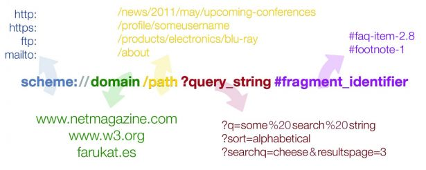

- *via*: [`http://www.creativebloq.com/design/design-perfect-url-1126509`](http://www.creativebloq.com/design/design-perfect-url-1126509)

# Absolute URLs

- **absolute urls**: link to an external site

```html
<a href="http://matt.curinga.com">click here</a>
```

# Relative URLs

- **relative urls**: link to a resource on the same website

```html
<strong>Navigation</strong>
<ul>
  <li><a href="home.html">Home</li>
  <li><a href="news.html">News</li>
  <li><a href="about.html">About</li>
</ul>
```

# Relative from root

- URLs starting with a forward slash (`/`) start from the root of the website
- this allows developers to link to resources without having to know where it is relative to the linking page
- makes it easier to **reuse** code snippets on multiple pages

```html
<strong>Navigation</strong>
<ul>
  <li><a href="/home.html">Home</li>
  <li><a href="/news.html">News</li>
  <li><a href="/about.html">About</li>
  <li><a href="/about/matt.html">About</li>
  <li><a href="/about/hannah.html">About</li>
</ul>
```

# Internal links

- can be used to “jump” to a section of a page
- you can declare anchors (jump targets) by using the `id` attribute on an html element
- the link starts with the `#` sign

```html
<a href="http://en.wikipedia.org/wiki/Hypertext#History">Go to Wikipedia
HyperText article and jump to the history section</a>
```

```html
<!-- from wikipedia page -->
<h2 id="history">History</h2>
<p><a href="/wiki/Hypertext" title="Hypertext">Hypertext</a> (...)</p>
```

# Title attribute

- `a` tags have an optional `title` attribute
- the title gives more information to the user before they click a link
- it’s often in the form of a tool tip
- titles also provide additional semantic information about a page

```html
<a href="http://matt.curinga.com"
   title="check out my home page">click here</a>
```

# Link to a stylesheet

- a stylesheet on the same webs server, *relative link*

```html
<link href="css/labor3.css" type="text/css" rel="stylesheet" />
```